# index

should import Pandas (import pandas as pd) and Matplotlib (import matplotlib.pyplot as plt) for data manipulation and visualization.

```python
import matplotlib.pyplot as plt
import pandas as pd
```

Explain: Importing pandas is able to calculate big datas.It’s Python excel

### 2. Load the Dataset

Load the Titanic dataset from a CSV file named 'titanic.csv' into a Pandas DataFrame.

```python
ti=pd.read_csv('titanic.csv')
```

```python
print(ti)
```

```
     PassengerId  Survived  Pclass  \
0              1         0       3
1              2         1       1
2              3         1       3
3              4         1       1
4              5         0       3
..           ...       ...     ...
886          887         0       2
887          888         1       1
888          889         0       3
889          890         1       1
890          891         0       3

                                                  Name     Sex   Age  SibSp  \
0                              Braund, Mr. Owen Harris    male  22.0      1
```

[output cut: 25 more lines]

Explain:Before knowing data type, we need to mean and load titianic

### 3. Data Exploration

Display the first few rows of the dataset to understand its structure.

Print information about the columns and their data types.

Show summary statistics for numerical columns (e.g., mean, min, max, etc.)

```python
print(ti.info())
print(ti.shape)
```

```
<class 'pandas.core.frame.DataFrame'>
RangeIndex: 891 entries, 0 to 890
Data columns (total 12 columns):
 #   Column       Non-Null Count  Dtype
---  ------       --------------  -----
 0   PassengerId  891 non-null    int64
 1   Survived     891 non-null    int64
 2   Pclass       891 non-null    int64
 3   Name         891 non-null    object
 4   Sex          891 non-null    object
 5   Age          714 non-null    float64
 6   SibSp        891 non-null    int64
 7   Parch        891 non-null    int64
 8   Ticket       891 non-null    object
 9   Fare         891 non-null    float64
 10  Cabin        204 non-null    object
 11  Embarked     889 non-null    object
dtypes: float64(2), int64(5), object(5)
memory usage: 83.7+ KB
None
(891, 12)
```

```python
print(ti['Age'].mean())
print(ti['Age'].median())
print(ti['Age'].min())
print(ti['Age'].max())
print(sum(ti['Age']))
print(sum(ti['Age'])/len(ti['Age']))#Age average
print(ti['Fare'].mean())
print(ti['Fare'].median())
print(ti['Fare'].min())
print(ti['Fare'].max())
print(sum(ti['Fare'])/len(ti['Fare']))#Fare average
```

```
29.69911764705882
28.0
0.42
80.0
nan
nan
32.204207968574636
14.4542
0.0
512.3292
32.204207968574636
```

Explain:Viewing datas type and calculating mean、median....

### 4. Data Cleaning

Identify and handle missing values in the dataset (e.g., fill missing age values with median).

Perform any necessary data transformations or cleaning steps

```python
print(ti.isnull().sum())
```

```
PassengerId      0
Survived         0
Pclass           0
Name             0
Sex              0
Age            177
SibSp            0
Parch            0
Ticket           0
Fare             0
Cabin          687
Embarked         2
dtype: int64
```

Explain:xx.isnull().sum() can find all field missing value

```python
ti=ti.dropna(subset=["Embarked"])
ti['Cabin']=ti['Cabin'].fillna("NoCabin")
```

```python
print(ti.isnull().sum())
```

```
PassengerId      0
Survived         0
Pclass           0
Name             0
Sex              0
Age            177
SibSp            0
Parch            0
Ticket           0
Fare             0
Cabin            0
Embarked         0
dtype: int64
```

Explain:find missing value one moretime

```python
ti=ti.fillna(ti['Age'].median())
print(ti.isnull().sum())
```

```
PassengerId    0
Survived       0
Pclass         0
Name           0
Sex            0
Age            0
SibSp          0
Parch          0
Ticket         0
Fare           0
Cabin          0
Embarked       0
dtype: int64
```

Explain:Use median to fill missing(age)

### 5. Data Analysis

Calculate and display the count of passengers by gender.

Compute the average age of passengers.

Determine the survival rate by passenger class.

```python
print(ti['Sex'].value_counts())
print(sum(ti['Age']))
print(sum(ti['Age'])/len(ti['Age']))#average
print(ti['Survived'].value_counts(normalize=True))
print(ti['Pclass'].value_counts())
Sr=ti.groupby('Pclass')['Survived'].mean()
```

```
Sex
male      577
female    312
Name: count, dtype: int64
26061.17
29.315151856017994
Survived
0    0.617548
1    0.382452
Name: proportion, dtype: float64
Pclass
3    491
1    214
2    184
Name: count, dtype: int64
```

Explain:Recalculate Age average and Use groupby code to determine survival rate by passenger class.

### 6. Data Visualization

Create a bar chart to visualize the survival rate by passenger class.

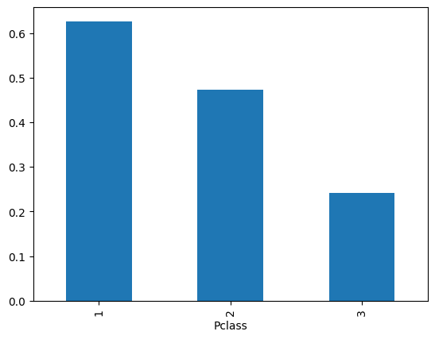

```python
Sr.plot.bar()
plt.show()
```

Explain:According to bar chart ,Pclass 1 survival rate is highest than others

### 7. Conclusion

Summarize your findings or insights gained from analyzing the Titanic dataset.

Reflect on the importance of data cleaning and exploration in data analysis.

Ans:Solvling missing values and arranging datas make data analysis be more complete.thus ,arranging datas is very important